# Assignment 7 Collaborative Coding

### February 24, 2016

#### **Summary Information**

Based on the survey taken at the beginning of this quarter, there are **15** freshman, **41** sophomores, **18** juniors, and **7** seniors in the class that completed the survey.

When examining the Operating Systems that the class uses, we found the number of students that use Mac or Windows Operating Systems. Out of the sample **39** students use a Mac operating system, while **40** students use a Windows OS.

Of the people that responded to the survey, **67** said that they were going to apply to the Informatics major, while **9** responded “maybe” and only **3** saying that they would not apply to the Informatics major.

As for sports fans that responded to the survey, **67** responded that they were Seahawks fans while **14** said that they were not Seahawks fans. This turns out to be **83** percent of the people that responded to the survey as Seahawks fans while **17** percent are not Seahawks fans.

Lastly, students were asked at the beginning of the quarter how familiar they were with the programming language R. **4** people reported that they were “Intermediate Users”, **7** people said that they had used it a few times before taking the class, and **70** people had no previous experience in R before taking this class.

#### **Data Visualization #1**

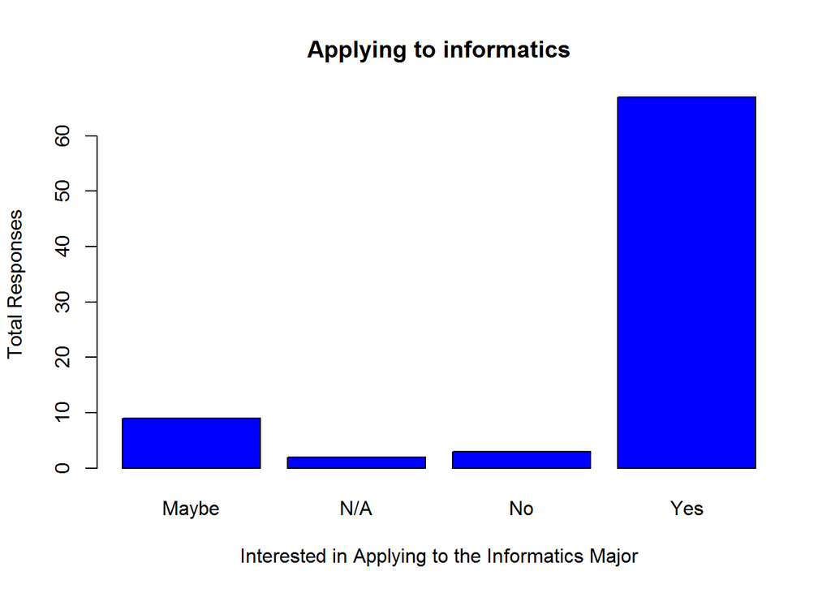

#### **Data Visualization #2**

[interactive chart not shown]